# Visualizando dados municipais com o R

José de Jesus Filho

6/27/2018

## Visualizando dados municipais

Nesta breve postagem irei mostrar como visualizar indicadores dos municípios brasileiros usando o R. A primeira coisa a fazer é instalar o pacote da Associação Brasileira de Jurimetria chamado `brcities`

```r
devtools::install_github("abjur/brcities")
```

O propósito do pacote `brcities` é baixar alguns indicadores municipais do Instituto Brasileiro de Geografia e Estatística. Se você quiser saber mais sobre esse pacote, leia o readme dele: brcities.

Agora que o instalamos, iremos carregá-lo juntamente com os pacotes do tidyverse. Se você não tem os pacotes do tidyverse, sugiro instalá-los, preferivelmente a versão em desenvolvimento: tidyverse. Igualmente, necessitaremos do pacote `sf`, muito útil para a manipulação de dados espaciais e do pacote leaflet, para visualização interativa.

```r
library(brcities)
library(sf)
library(tidyverse)
library(leaflet)
```

Agora iremos carregar a população estimada do estado do Pernambuco. Para tanto, utilizamos a função br_city_indicators. Esta função não somente baixa os dados autalizados do IBGE, como também junta nela dados como latitude e longitude.

```r
pop_pe<-br_city_indicators(uf="pe",indicators=29171)
```

O próximo passo é baixar o mapa do estado do Pernambuco. Você encontra este e outros mapas no seguinte link: IBGE. O procedimento a seguir baixa, expande e importa o polígono. Depois de expandir o arquivo “.zip”, você notará que seis arquivos são extraídos, todos com o mesmo nome, mas com diferentes extensões. A função `st_read()` do pacote `sf` é inteligente o suficiente converter todos esses arquivos em um único objeto conhecido como `simple feature`, você só tem de indicar qual deles é o shapefile, isto é, aquele com extensão `.shp`.

Há um outro link, o qual permite baixar os shapes dos municípios, mas a última atualização é de 2016

```r
download.file("ftp://geoftp.ibge.gov.br/organizacao_do_territorio/malhas_territoriais/malhas_municipais/municipio_2015/Brasil/BR/BR.zip","br.zip")
unzip("br.zip")
mapa_pe<-st_read("26MUE250GC_SIR.shp") %>%
  filter(str_detect(CD_GEOCMU,"^26"))
```

Temos agora de juntar esses dois arquivos num só. Se você rodar a função `glimpse()` nos dois, verá que eles têm uma veriável comum, que é o código do IBGE, mas com nomes diferentes. Além disso, um deles é fator e outro é numérico e num deles o código tem seis digitos e no outro, sete digitos. Ademais, as estimativas populacionais estão em formato caractere, temos de convertê-las para números. O procedimento toma conta desses ajustes e junta os arquivos.

```r
mapa_pe<-mapa_pe %>%
  mutate(CD_GEOCMU=CD_GEOCMU %>%
           as.character() %>%
           as.numeric() %>%
           divide_by(10) %>%
           floor()) %>%
  left_join(pop_pe,by=c("CD_GEOCMU" = "city_code")) %>%
  rename(pop_2016=populacao_estimadares.2016,pop_2017=populacao_estimadares.2017) %>%
  mutate_at(c("pop_2016","pop_2017"),as.numeric)
```

Pronto, agora é só plotar o mapa usando o pacote ggplot2, o qual integra o tidyverse.

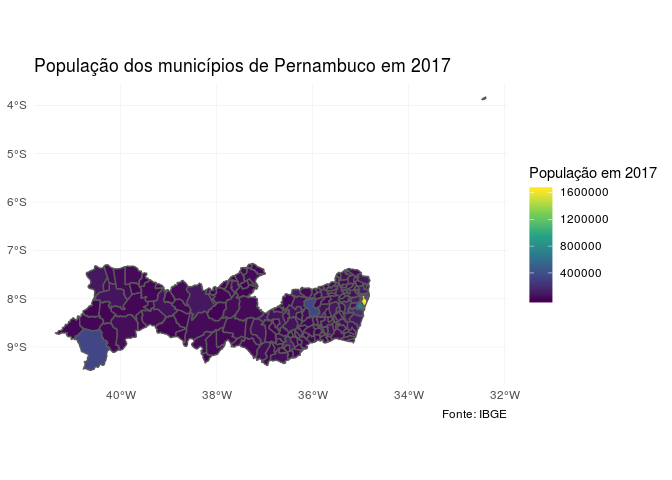

```r
ggplot() +
  geom_sf(data = mapa_pe, aes(fill = pop_2017)) +
  scale_fill_viridis_c(name="População em 2017") +
  labs(title="População dos municípios de Pernambuco em 2017",caption="Fonte: IBGE")+
  theme_minimal()
```

Se você quiser deixar seu mapa interativo para as pessoas passarem o mouse sobre o município e ver a população, o pacote `leafleat` vem a calhar.

```r
quantis <- quantile(mapa_pe$pop_2017)
pal <- colorBin("YlOrRd", domain = mapa_pe$pop_2017, bins = quantis)

labels <- sprintf(
  "<strong>%s</strong><br/> população: %g",
  mapa_pe$city_name, mapa_pe$pop_2017
) %>% lapply(htmltools::HTML)

leaflet(mapa_pe) %>%
  fitBounds(-41.358336,  -9.482897, -32.390914 , -3.828719) %>%
  addTiles() %>%
  addPolygons(
    fillColor = ~pal(pop_2017),
    weight = 2,
    opacity = 1,
    color = "white",
    dashArray = "3",
    fillOpacity = 0.7,
    highlight = highlightOptions(
      weight = 5,
      color = "#666",
      dashArray = "",
      fillOpacity = 0.7,
      bringToFront = TRUE),
    label = labels,
    labelOptions = labelOptions(
      style = list("font-weight" = "normal", padding = "3px 8px"),
      textsize = "15px",
      direction = "auto")) %>%
  addLegend(pal = pal, values = ~pop_2017, opacity = 0.7, title = NULL,
    position = "bottomright",labFormat = labelFormat(big.mark = "."))
```

[interactive chart not shown]